# Sentinel selection and conditional analysis

Nomei Nicole Piga

25 May, 2023

```r
#library reticulate to be able to add chuncks in another language
library(reticulate)
# To run this .rmd file in a terminal being in the project folder:
#export PATH=${PATH}:/cm/shared/apps/R/deps/rstudio/bin/pandoc
#file="./report/Sentinel_and_conditional_analysis.Rmd"
#module unload R/4.2.1
#module load R/4.1.0
#Rscript -e 'rmarkdown::render("'$file'")'
```

# Rationale

Sentinel selection, loci, and conditional analysis for the genome-wide significant regions discovered by the GWAS on severe asthma European ancestry participants in UK Biobank.

# Analysis

## Variant and loci selection

Code: src/broad_phenotype/postGWAS_analyses.sh

```r
#!/bin/bash

#PBS -N post_gwas_asthma_broadpheno
#PBS -j oe
#PBS -o post_gwas_asthma_broadpheno
#PBS -l walltime=3:0:0
#PBS -l vmem=50gb
#PBS -l nodes=1:ppn=1
#PBS -d .
#PBS -W umask=022


#Set variables:
PATH_OUT="/home/n/nnp5/PhD/PhD_project/REGENIE_assoc/output"
PHENO="broad_pheno_1_5_ratio"

#PHENO to change into:
#"broad_pheno_1_5_ratio"
#"broad_pheno_female"
#"broad_pheno_male"
#"broad_pheno_adultonset"
#"broad_pheno_childhoodonset"
#"broad_pheno_1_5_ratio"
test_type="recessive" #additive: NULL. use ONLY  this variable only with dominant or recessive test
test_type_underscore="recessive_" #additive: NULL. use ONLY  this variable only with dominant or recessive test

#N of individuals, to change:
tot_n=46086
#tot_n for broad pheno (additive recessive and dominant): 46086
#tot_n for broad pheno female: 29646
#tot_n for broad pheno male: 16440
#tot_n for broad pheno adultonset: 42919
#tot_n for broad pheno childhoodonset: 39944

#mkdir ${PATH_OUT}/allchr
GWAS="/home/n/nnp5/PhD/PhD_project/REGENIE_assoc/output/allchr"


#merge all assoc file:
#zcat ${PATH_OUT}/${PHENO}.1.${test_type}regenie.step2_${PHENO}.regenie.gz | tail -n +2 | \
#     awk -F " " '{print $1, $2, $3, $4, $5, $6, $7, $8, $9, $10, $11, $12, $13}' \
#    > ${GWAS}/${PHENO}_${test_type}allchr.assoc.txt

#for i in {2..22}
#    do zcat ${PATH_OUT}/${PHENO}.${i}.${test_type}regenie.step2_${PHENO}.regenie.gz | \
#    tail -n +2 | awk -F " " '{print $1, $2, $3, $4, $5, $6, $7, $8, $9, $10, $11, $12, $13}' \
#    >> ${GWAS}/${PHENO}_${test_type}allchr.assoc.txt
#done

#gzip ${GWAS}/${PHENO}_${test_type}allchr.assoc.txt

#create input ldsc file both for all vars and maf >= 0.01.
#module unload R/4.2.1
#module load R/4.1.0
#chmod o+x src/create_input_munge_summary_stats.R
#dos2unix src/create_input_munge_summary_stats.R
#Rscript src/create_input_munge_summary_stats.R \
#    ${GWAS}/${PHENO}_${test_type}allchr.assoc.txt.gz \
#    ${PHENO}_${test_type}

#LDSC interactively.
#The results are the same for set with all vars and fitlered maf 0.01., because LDSC uses only vars > 0.01. So run
#on the filtered set
#cd /home/n/nnp5/software/ldsc
#conda activate ldsc

PHENO="maf001_broad_pheno_1_5_ratio"
#"maf001_broad_pheno_1_5_ratio" for additive, recessive, dominant models
#"maf001_broad_pheno_female"
#"maf001_broad_pheno_male"
#"maf001_broad_pheno_adultonset"
#"maf001_broad_pheno_childhoodonset"

#awk '{print $1, $2, $3, $4, $5, $6, $7, $8, $9}' ${PATH_OUT}/${PHENO}_${test_type_underscore}betase_input_mungestat \
#    > ${PATH_OUT}/${PHENO}_${test_type_underscore}betase_input_mungestat_clean

#interactively:
#/home/n/nnp5/software/ldsc/munge_sumstats.py \
#--sumstats ${PATH_OUT}/${PHENO}_${test_type_underscore}betase_input_mungestat_clean \
#--N ${tot_n}   \
#--out ${PATH_OUT}/${PHENO}_${test_type_underscore}allchr_step2_regenie \
#--merge-alleles /data/gen1/UKBiobank/Smoking/Meta_Analysis_AWI_UGR_UKBAFR/files/w_hm3.snplist \
#--chunksize 500000

#/home/n/nnp5/software/ldsc/ldsc.py \
#--h2 ${PATH_OUT}/${PHENO}_${test_type_underscore}allchr_step2_regenie.sumstats.gz \
#--ref-ld-chr /data/gen1/reference/ldsc/eur_w_ld_chr/ \
#--w-ld-chr /data/gen1/reference/ldsc/eur_w_ld_chr/ \
#--out ${PATH_OUT}/${PHENO}_${test_type_underscore}allchr_step2_regenie_h2

#conda deactivate
#cd /home/n/nnp5/PhD/PhD_project/REGENIE_assoc/

#Plots:
ldsc_intercept=1.00
#broad pheno:'1.02'
#broad pheno female:'1.02'
#broad pheno adultonset:'1.00'
#broad pheno male:'1.04'
#broad pheno childhoodonset:'1.02'
#broad pheno dominant:'1.01'
#broad pheno recessive:'1.00'

#run Manhattan, qqplot, lambda for vars with maf >= 0.01:
module unload R/4.2.1
module load R/4.1.0
chmod o+x src/REGENIE_plots.R
dos2unix src/REGENIE_plots.R
Rscript src/REGENIE_plots.R \
    ${PATH_OUT}/${PHENO}_${test_type_underscore}betase_input_mungestat \
    ${PHENO}_${test_type} \
    ${ldsc_intercept}

#extract only genome-wide significant variants:
#awk -F "\t" '$9 <= 0.00000005 {print $0}' ${PATH_OUT}/${PHENO}_${test_type_underscore}betase_input_mungestat \
#    > ${PATH_OUT}/${PHENO}_${test_type_underscore}genomewide_signif

#Sentinel selection:
#module unload R/4.2.1
#module load R/4.1.0
#chmod o+x src/sentinel_selection.R
#dos2unix src/sentinel_selection.R
#Rscript src/sentinel_selection.R \
#    ${PATH_OUT}/${PHENO}_${test_type_underscore}betase_input_mungestat \
#    ${PHENO} \
#    500000 \
#    0.00000005 \
#    ${test_type}

#create OddsRatio and direction of effect using Create_oddsratio.R
#Rscript src/broad_phenotype/Create_oddsratio.R ${PATH_OUT}/${PHENO}${test_type}_sentinel_variants.txt ${PATH_OUT}/${PHENO}_${test_type_underscore}sentinel_variants_OR.txt
```

Code: src/create_input_munge_summary_stats.R

```r
#!/usr/bin/env Rscript

library(data.table)
library(tidyverse)

args = commandArgs(trailingOnly=TRUE)
df_file <- args[1]
pheno <- as.character(args[2])

df <- fread(df_file,header=F)

#CHROM GENPOS ID ALLELE0 ALLELE1 A1FREQ INFO N TEST BETA SE CHISQ LOG10P
#REGENIE: reference allele (allele 0), alternative allele (allele 1)
#REGENIE:  estimated effect sizes (for allele 1 on the original scale)

colnames(df) <- c("CHROM", "GENPOS", "ID", "ALLELE0", "ALLELE1", "A1FREQ", "INFO", "N","TEST", "BETA", "SE", "CHISQ", "LOG10P")
dfclean <- df %>% select(CHROM,ID,GENPOS,ALLELE1,ALLELE0,A1FREQ,LOG10P,BETA,SE)

dfclean$pval <- 10^(-dfclean$LOG10P)

#select column in order:
dfclean <- dfclean %>% select(ID,CHROM,GENPOS,ALLELE1,ALLELE0,BETA,SE,A1FREQ,pval)

#rename columns :
colnames(dfclean) <- c("snpid", "b37chr", "bp", "a1", "a2", "LOG_ODDS", "se", "eaf", "pval")
#save gwas all chr results:

#write.table(dfclean,paste0("output/",pheno,"_betase_input_mungestat"),quote=FALSE,sep="\t",row.names=FALSE)


#make sure eaf column is numeric:
dfclean$eaf <- as.numeric(dfclean$eaf)

#create MAF columns and filtered out for MAF >= 0.01:
dfclean <- dfclean %>% mutate(MAF = ifelse(dfclean$eaf <= 0.5, dfclean$eaf, 1 - dfclean$eaf))
dfclean_MAF001 <- dfclean %>% filter(MAF >= 0.01)

#save gaws results for variants with MAF >= 0.01:
write.table(dfclean_MAF001,paste0("output/maf001_",pheno,"_betase_input_mungestat"),quote=FALSE,sep="\t",row.names=FALSE)
```

Code: src/sentinel_selection.R

```r
sink(stderr())

args <- commandArgs(T)
argc <- length(args)

if (argc < 1) {
    cat("Usage: sentinels.R HITS [ WIDTH (default", WIDTH, ")]\n")
    q()
}

tier_file = args[1]
pheno = args[2]
WIDTH <- ifelse(argc > 2, as.integer(args[3]), 500000)
p_val_thresh = as.numeric(args[4])
pheno_2 = args[5]

print(paste0("total genomic window used for signal selection:",2*WIDTH))

suppressMessages(library(data.table))
suppressMessages(library(tidyverse))


selectSentinels <- function(data.dt) {
    regions.list <- list()
    while(nrow(data.dt) > 0) {
        top.dt <- data.dt[ which.min(pval) ]
        regions.list[[top.dt$snpid]] <- top.dt
        data.dt <- data.dt[ b37chr != top.dt$b37chr
            | bp <= top.dt$bp - WIDTH
            | bp >= top.dt$bp + WIDTH ]
    }
    rbindlist(regions.list)
}


tier.dt <- fread(tier_file,header=T)
tier.dt <- tier.dt %>% filter(pval <= p_val_thresh)
sentinels.dt <- selectSentinels(tier.dt)
sentinels.dt <- sentinels.dt %>% arrange(b37chr)
write.table(sentinels.dt, paste0("output/",pheno,pheno_2,"_sentinel_variants.txt"), row.names=F, quote=F, sep="\t")


#Compare with Lancet results:
lancet_file <- "/data/gen1/AIRPROM/assoc/severe_asthma/severe_asthma_signals.txt"
lancet <- fread(lancet_file,header=T,fill=T)
lancet <- lancet %>% rename(b37chr="chrom")
lancet <- lancet %>% rename(bp=pos)
print(inner_join(sentinels.dt,lancet,by=c("b37chr","bp")))
```

Code: src/broad_phenotype/Create_oddsratio.R

```r
#!/usr/bin/env Rscript


suppressMessages(library(tidyverse))
suppressMessages(library(data.table))

args = commandArgs(trailingOnly=TRUE)

input_file = args[1]
output_file = args[2]


#input:
sumstat <- read.table(input_file,header=T)

#create odds_ratio ci_lower ci_upper
sumstat$odds_ratio <- exp(sumstat$LOG_ODDS)
sumstat$ci_lower <- exp(sumstat$LOG_ODDS - qnorm(0.975)*sumstat$se)
sumstat$ci_upper <- exp(sumstat$LOG_ODDS + qnorm(0.975)*sumstat$se)

#create unique column:
sumstat$'OR_95_CI' <- paste0(format(round(sumstat$odds_ratio,2),nsmall=2)," [",format(round(sumstat$ci_lower,2),nsmall=2),"-",format(round(sumstat$ci_upper,2),nsmall=2),"]")

#direction of effect:
sumstat <- sumstat %>% mutate(direction_of_effect=ifelse(sumstat$LOG_ODDS > 0, "+","-"))

write.table(sumstat,output_file,sep="\t",quote=F,row.names=F)
```

Code: Post_GWAS/src/merge_loci.R

```r
sink(stderr())

suppressMessages(library(GenomicRanges))
suppressMessages(library(tidyverse))

args <- commandArgs(T)
argc <- length(args)

sentinels_file <- args[1]
width <- ifelse(argc > 1, args[2] %>% as.integer, 1e6)
gap <- ifelse(argc > 2, args[3] %>% as.integer, 5e5)
output_file <- args[4]

print(paste0("Merge sentinel regions. Regions : +/-",width,". Minimum distance between region: ",gap))

sentinels <- read_tsv(sentinels_file) %>%
    arrange(b37chr, bp) %>%
    mutate(idx=1:n(), start=bp - width, end=bp + width)

colnames(sentinels)[1] <- "rsid"
colnames(sentinels)[2] <- "chrom"
colnames(sentinels)[3] <- "pos"



sentinels.overlaps <- makeGRangesFromDataFrame(sentinels) %>%
    findOverlaps(maxgap = gap) %>%
    as_tibble %>%
    filter(queryHits != subjectHits) %>%
    mutate(hash=queryHits^2 * subjectHits^2) %>%
    group_by(hash) %>%
    slice(1) %>%
    ungroup %>%
    mutate(merge1=sentinels %>% slice(queryHits) %>% pull(rsid),
           merge2=sentinels %>% slice(subjectHits) %>% pull(rsid)) %>%
    select(merge1, merge2)

sentinels <- left_join(sentinels, sentinels.overlaps, c("rsid" = "merge1"))

sentinels <- sentinels %>%
    mutate(ismerge=ifelse(!is.na(merge2),1,0),
           diffmerge=c(0,diff(ismerge)),
           newlocus=ifelse(ismerge == diffmerge, 1, 0),
           locus=paste0("locus", cumsum(newlocus)))

loci <- sentinels %>%
    mutate(merge2=ifelse(is.na(merge2), "", merge2)) %>%
    group_by(locus) %>%
    summarise(first=first(rsid),
              merge.list=unique(merge2) %>% paste(collapse=" ") %>% str_trim)

sink()
write.table(loci, output_file, row.names = F, sep = "\t", quote=F)
```

Code: Post_GWAS/src/Merge_sentinel_region.sh

```r
#!/bin/bash

PATH_OUT="/home/n/nnp5/PhD/PhD_project/REGENIE_assoc/output"
PHENO="maf001_broad_pheno_1_5_ratio"

cp /data/gen1/LF_HRC_transethnic/scripts/signal_selection/merge_loci.R \
    src/


#Merge sentinel region less than 500Kb apart:
module unload R/4.2.1
module load R/4.1.0
chmod o+x src/merge_loci.R
dos2unix src/merge_loci.R
Rscript src/merge_loci.R ${PATH_OUT}/${PHENO}_sentinel_variants.txt \
    1000000 \
    500000 \
    /home/n/nnp5/PhD/PhD_project/Post_GWAS/output/merged_sentinel_loci.txt
```

Variants with a p-value equal to or below the genome-wide significant threshold of 5e-8 were extracted and the sentinel variant for each genomic loci was chosen as the one with the lowest p-value in its surrounding region of 1Mb (+/- 500Kb). If some loci were less than 500Kb apart, the loci were merged.

## Conditional analysis

Code: Post_GWAS/src/plink_conversion_file.sh

```r
#!/bin/bash

#PBS -N plink_conversion_files
#PBS -j oe
#PBS -o log
#PBS -l walltime=6:0:0
#PBS -l nodes=1:ppn=4
#PBS -l vmem=60gb
#PBS -W umask=022

chr=$PBS_ARRAYID
pheno="broad_pheno"

##requires to create the input for --keep option: --keep input/${pheno}_individuals
## run as: qsub -t 4,7,13,16,19,21,22 src/plink_conversion_files.sh

#create individual files for --keep parameter:
#awk '{print $1, $1}' /data/gen1/UKBiobank_500K/severe_asthma/Noemi_PhD/data/eid_demo_EUR_pheno_cov_broadasthma.txt | \
#    sed -e '1i\IID FID' > /home/n/nnp5/PhD/PhD_project/Post_GWAS/input/broadasthma_individuals

#prep plink file with my case/control individuals and save them in scratch:
module load plink2
plink2 \
    --bgen /data/ukb/nobackup/imputed_v3/ukb_imp_chr${chr}_v3.bgen \
    ref-first --sample /data/gen1/UKBiobank_500K/severe_asthma/data/ukbiobank_app56607_for_regenie.sample \
    --keep /home/n/nnp5/PhD/PhD_project/Post_GWAS/input/broadasthma_individuals \
    --make-bed --out /scratch/gen1/nnp5/REGENIE_assoc/tmp_data/${pheno}_plink_file_v3_chr${chr}
```

Code: Post_GWAS/src/pre_processing_files.sh

```r
#!/bin/bash

#PBS -N pre_processing_files_GCTAcond
#PBS -j oe
#PBS -o pre_processing_files_GCTAcond
#PBS -l walltime=6:0:0
#PBS -l nodes=1:ppn=4
#PBS -l vmem=60gb
#PBS -W umask=022

chr=$PBS_ARRAYID
pheno="broad_pheno"

#GWASsumstat.ma
#SNP A1 A2 freq b se p N
#rs1001 A G 0.8493 0.0024 0.0055 0.6653 129850
#rs1002 C G 0.0306 0.0034 0.0115 0.7659 129799
#The headers are not keywords and will be omitted by the program.
# Important: "A1" needs to be the effect allele with "A2" being the other allele and "freq" should be the frequency of "A1".
#
#Note: 1) For a case-control study, the effect size should be log(odds ratio) with its corresponding standard error.
#2) Please always input the summary statistics of all SNPs even if your analysis only focuses on a subset of SNPs
#because the program needs the summary data of all SNPs to calculate the phenotypic variance.


awk '{print $1, $4, $5, $8, $6, $7, $9, '46086'}' \
    /home/n/nnp5/PhD/PhD_project/REGENIE_assoc/output/maf001_${pheno}_1_5_ratio_betase_input_mungestat_clean | \
    sed "1s/.*/SNP A1 A2 freq b se p N/" >  /home/n/nnp5/PhD/PhD_project/Post_GWAS/input/${pheno}_GWASsumstat.ma

#sentinels.snplist
#awk '{print $1}' /home/n/nnp5/PhD/PhD_project/REGENIE_assoc/output/maf001_${pheno}_1_5_ratio_sentinel_variants.txt | \
#    tail -n +2 \
#    >  /home/n/nnp5/PhD/PhD_project/Post_GWAS/input/${pheno}_sentinels.snplist

##Create the plink file:
##qsub -t 1-22 src/plink_conversion_files.sh
```

Code: Post_GWAS/src/GCTA_cojocond.sh

```r
#!/bin/bash

#PBS -N GCTA_cojoslct
#PBS -j oe
#PBS -o log_GCTA_cojoslct
#PBS -l walltime=2:0:0
#PBS -l nodes=1:ppn=4
#PBS -l vmem=90gb
#PBS -W umask=022

#run after Merge_sentinel_region.sh
#Manually create the /home/n/nnp5/PhD/PhD_project/Post_GWAS/input/regions_merged_for_cond from Merge_sentinel_region.sh output
#output was: /home/n/nnp5/PhD/PhD_project/Post_GWAS/output/merged_sentinel_loci.txt

#GCTA using --cojo-slct parameter
#run as: qsub /home/n/nnp5/PhD/PhD_project/Post_GWAS/src/GCTA_cojocond.sh

pheno="broad_pheno"
module load plink

#Some sentinels have overlapping regions, therefore i extract the whole region and run the conditional analysis on the whole region
#taking into account multiple sentinels. This is the case for sentinel on chromosome 5 (rs2188962,rs152815)
#and on chromosome 12 (rs9271365,rs3024971). Chromosome 6: do not run conditional.
#run cgta-condcojo:

for line in {2..14}
do
SNP=$(awk -v row="$line" ' NR == row {print $1 } ' /home/n/nnp5/PhD/PhD_project/Post_GWAS/input/regions_merged_for_cond)
chr=$(awk -v row="$line" ' NR == row {print $2 } ' /home/n/nnp5/PhD/PhD_project/Post_GWAS/input/regions_merged_for_cond)
start=$(awk -v row="$line" 'NR == row {print $4}' /home/n/nnp5/PhD/PhD_project/Post_GWAS/input/regions_merged_for_cond)
end=$(awk -v row="$line" 'NR == row {print $5}' /home/n/nnp5/PhD/PhD_project/Post_GWAS/input/regions_merged_for_cond)
plink \
    --bfile /scratch/gen1/nnp5/REGENIE_assoc/tmp_data/${pheno}_plink_file_v3_chr${chr} \
    --chr ${chr} --from-bp ${start} --to-bp ${end} \
    --make-bed --out /scratch/gen1/nnp5/REGENIE_assoc/tmp_data/${pheno}_plink_file_v3_chr${chr}_${SNP}

    /home/r/rja34/bin/gcta_1.90.2beta/gcta64 \
    --bfile  /scratch/gen1/nnp5/REGENIE_assoc/tmp_data/${pheno}_plink_file_v3_chr${chr}_${SNP} \
    --cojo-file /home/n/nnp5/PhD/PhD_project/Post_GWAS/input/${pheno}_GWASsumstat.ma \
    --cojo-slct \
    --cojo-p 5e-8 \
    --maf 0.01 \
    --cojo-actual-geno \
    --exclude /data/gen1/UKBiobank_500K/imputed/multiallelic.snps \
    --out /home/n/nnp5/PhD/PhD_project/Post_GWAS/output/cojoslct_chr${chr}_${SNP}
done


#write results for genome-wide variants:
cat /home/n/nnp5/PhD/PhD_project/Post_GWAS/output/cojoslct_chr${chr}_${SNP}.jma.cojo | sort -u | head -n -1 | \
    sed "1s/.*/Chr  SNP bp  refA  freq  b se  p n freq_geno bJ  bJ_se pJ  LD_r/" \
    > /home/n/nnp5/PhD/PhD_project/Post_GWAS/output/cojoslct_genomewide

awk '$1 !=6 && $13 <= 0.00000005' /home/n/nnp5/PhD/PhD_project/Post_GWAS/output/cojoslct_chr*.jma.cojo \
    >> /home/n/nnp5/PhD/PhD_project/Post_GWAS/output/cojoslct_genomewide

#one additional signal on chromsome 10 (rs1444789): check ld with sentinel rs201499805:
#they are independent:
plink --bfile /scratch/gen1/nnp5/REGENIE_assoc/tmp_data/broad_pheno_plink_file_v3_chr10 \
    --ld rs201499805 rs1444789 \
    > /home/n/nnp5/PhD/PhD_project/Post_GWAS/output/rs201499805_rs1444789_ld

#add new independent variant (rs1444789) to the sentinel variant:
##NB: sicne I have to change a space into a tab, this command needs to be run interactively and manually input the tab every time:
echo "rs1444789 10 9064361 C T 0.141266 0.0240968 0.186346 4.56104e-09 0.186346" | sed 's/ /        /g' | \
    cat  /home/n/nnp5/PhD/PhD_project/REGENIE_assoc/output/maf001_broad_pheno_1_5_ratio_sentinel_variants.txt - \
    >  /home/n/nnp5/PhD/PhD_project/Post_GWAS/output/SA_sentinel_variants_after_conditional.txt
```

In order to investigate if there were other independently associated variants, I used the GCTA conditional analysis software with the –cojo-slct parameter which performs a stepwise model selection (v1.90.2beta) [1]. I analysed regions +/- 2Mb from the sentinel variants. The loci on chromosome 6 embrace the MHC region which has a complex LD structure; thus the conditional analysis is not used for this area.

Finally, Locus zoom plots were created using the free online tool LocusZoom v0.12 [2] to investigate the sentinel variants, their associated genomic loci, and surrounding genes (if any).

## Look-up of sentinel variants

Code: Post_GWAS/src/Lookup_in_modsev_imputed.R

```r
#!/usr/bin/env Rscript

library(tidyverse)
library(dplyr)
library(data.table)

#in bash:
#source /home/n/nnp5/PhD/PhD_project/UKBiobank_datafields/venv/bin/activate
#xlsx2csv -n 'Sheet1' input/Shrine_modsev_sentinel.xlsx > input/Shrine_modsev_sentinel.csv

modsev <- fread("/home/n/nnp5/PhD/PhD_project/Post_GWAS/input/Shrine_modsev_sentinel.csv")
UKBB_EUR <- fread("/data/gen1/UKBiobank_500K/severe_asthma/Noemi_PhD/data/maf001_broad_pheno_1_5_ratio_sentinel_variants_OR.txt")

columns= colnames(modsev)
modsev_in_loci <- data.frame(matrix(nrow = 0, ncol = length(columns)))
colnames(modsev_in_loci) = columns

for (i in seq(1,length(UKBB_EUR$snpid))) {
sentinel_var <- as.character(UKBB_EUR[i,1])
OR_sentinel_var <- UKBB_EUR[i,14]
pos_sentinel <- as.numeric(UKBB_EUR[i,3])
min_pos <- pos_sentinel - 1000000
max_pos <- pos_sentinel + 1000000
chr_sentinel <- as.numeric(UKBB_EUR[i,2])
modsev_in_loci_tmp <- modsev %>% filter(Chromosome == chr_sentinel) %>% filter(Position >= min_pos & Position <= max_pos)
modsev_in_loci_tmp$UKBB_sent_vars <- sentinel_var
modsev_in_loci_tmp$UKBB_sent_vars_OR_95_CI <- OR_sentinel_var
modsev_in_loci = rbind(modsev_in_loci, modsev_in_loci_tmp)
}

fwrite(modsev_in_loci,"/home/n/nnp5/PhD/PhD_project/Post_GWAS/output/lookup_broadpheno_sentvars_in_Shrinemodsevasthma.txt",quote=F,sep="\t",col.names=T,row.names=F)
```

Code: Post_GWAS/src/Lookup_in_modsev_sequencing.R

```r
#!/usr/bin/env Rscript

library(tidyverse)
library(dplyr)
library(data.table)

#in bash:
#source /home/n/nnp5/PhD/PhD_project/UKBiobank_datafields/venv/bin/activate
#xlsx2csv -n 'Sheet1' input/Cheng_modsev_sentinel.xlsx > input/Cheng_modsev_sentinel.csv

modsev <- fread("/home/n/nnp5/PhD/PhD_project/Post_GWAS/input/Cheng_modsev_sentinel.csv")
colnames(modsev)[3] <- "BP"
UKBB_EUR <- fread("/data/gen1/UKBiobank_500K/severe_asthma/Noemi_PhD/data/maf001_broad_pheno_1_5_ratio_sentinel_variants_OR.txt")
UKBB_EUR_GRCh38 <- fread("/home/n/nnp5/PhD/PhD_project/Post_GWAS/input/broadpheno_GRCh38.bed")

#Retrieve position in GRCh38:
UKBB_EUR_GRCh38 <- separate(data = UKBB_EUR_GRCh38, col = V4, into = c("chr:pos", "bp"), sep = "-")
UKBB_EUR_GRCh38$bp <- as.numeric(UKBB_EUR_GRCh38$bp)
UKBB_EUR$V1 <- as.character(paste0("chr",UKBB_EUR$b37chr))
UKBB_EUR_GRCh38$V1 <- as.character(UKBB_EUR_GRCh38$V1)
UKBB_EUR_GRCh38_sumstat <- inner_join(UKBB_EUR,UKBB_EUR_GRCh38,by=c("V1","bp"))
colnames(UKBB_EUR_GRCh38_sumstat)[17] <- "bp_GRCh38"
UKBB_EUR_GRCh38_sumstat <- UKBB_EUR_GRCh38_sumstat[,-c(16,18,19,20)]

columns= colnames(modsev)
modsev_in_loci <- data.frame(matrix(nrow = 0, ncol = length(columns)))
colnames(modsev_in_loci) = columns

for (i in seq(1,length(UKBB_EUR_GRCh38_sumstat$snpid))) {
sentinel_var <- as.character(UKBB_EUR_GRCh38_sumstat[i,1])
OR_sentinel_var <- UKBB_EUR_GRCh38_sumstat[i,14]
pos_sentinel <- as.numeric(UKBB_EUR_GRCh38_sumstat[i,16])
min_pos <- pos_sentinel - 1000000
max_pos <- pos_sentinel + 1000000
chr_sentinel <- as.numeric(UKBB_EUR_GRCh38_sumstat[i,2])
modsev_in_loci_tmp <- modsev %>% filter(CHR == chr_sentinel) %>% filter(BP >= min_pos & BP <= max_pos)
modsev_in_loci_tmp$UKBB_sent_vars <- sentinel_var
modsev_in_loci_tmp$UKBB_sent_vars_OR_95_CI <- OR_sentinel_var
modsev_in_loci = rbind(modsev_in_loci, modsev_in_loci_tmp)
}

fwrite(modsev_in_loci,"/home/n/nnp5/PhD/PhD_project/Post_GWAS/output/lookup_broadpheno_sentvars_in_Chengmodsevasthma.txt",quote=F,sep="\t",col.names=T,row.names=F)
```

Code: Post_GWAS/src/Lookup_snps_in_GBMI_asthma.sh

```r
#!/bin/bash

#download supplementary table: https://www.medrxiv.org/content/10.1101/2021.11.30.21267108v3.supplementary-material
#convert sentinel SNPs interactively with liftOver (GRCh37 to GRCh38): https://genome.ucsc.edu/cgi-bin/hgLiftOver
#and then download the file for broad pheno sentinel vars.
#here the command line for broad pheno sentinels:
#awk '{print "chr"$2, $3, $3}' /data/gen1/UKBiobank_500K/severe_asthma/Noemi_PhD/data/maf001_broad_pheno_1_5_ratio_sentinel_variants_OR.txt | \
#     tail -n +2 > input/input_broad_pheno_GRCh37_liftOver


source /home/n/nnp5/PhD/PhD_project/UKBiobank_datafields/venv/bin/activate
xlsx2csv input/GBMI_asthma_Supplementary_Tables.xlsx -n 'STable 2' | tail -n +2 \
    > input/GBMI_asthma_sentinels.csv


#Search for a locus of +/- 1000kb from sentinel variants and check the LD D'/R2 with GBMI sentinel variants:
module unload R/4.2.1
module load R/4.1.0
chmod o+x src/Lookup_GBMI_sentinelvars.R
Rscript src/Lookup_GBMI_sentinelvars.R

########################################################################################################################
####Not sure about this analysis:
#Option 3: for each chromosome, calculate the LD between the BTS45 sentinel vars and GBMI sentinel vars using European individuals
#and LD theshold of: D'>= 0.9 and R2 >= 0.6
##For GBMI variants withing +/- 1000kb from broad_pheno GWAS sentinel vars:

#For all GBMI variants tested against broad_pheno sentinel vars:
awk -F "," '{print $1}' input/GBMI_asthma_sentinels.csv | awk -F ";" '{print $1}' | tail -n +2 > input/GBMI_asthma_sentinels_chrpos.csv

#Subgroup of GBMI sentinel on chr3, chr6, chr12 to calculate LD with broad pheno sentinels:
awk '{if ($1 == "chr3" || $1 == "chr6" || $1 == "chr12") print $1":"$2}' input/GBMI_sentinel_vars_GRCh37.bed \
    > input/GBMI_asthma_sentinels_chr3_6_12


#In R:
dos2unix src/LDlink.R
chmod o+x src/LDlink.R
Rscript src/LDlink.R > output/LDlink_lookup_BTS45_and_broadpheno_sentvars_in_GBMI_asthma.txt
```

Code: Post_GWAS/src/Lookup_GBMI_sentinelvars.R

```r
#!/usr/bin/env Rscript

library(tidyverse)
library(dplyr)
library(data.table)


GBMI <- fread("/home/n/nnp5/PhD/PhD_project/Post_GWAS/input/GBMI_asthma_sentinels.csv", sep=",") %>% select("SNP ID; Risk allele","rsid","CHR","BP","REF","ALT","Gene.refGene","Beta","SE","Category")
UKBB_EUR <- fread("/data/gen1/UKBiobank_500K/severe_asthma/Noemi_PhD/data/maf001_pheno_1_5_ratio_sentinel_variants_OR.txt")
UKBB_EUR_GRCh38 <- fread("/home/n/nnp5/PhD/PhD_project/Post_GWAS/input/BTS45_GRCh38.bed", sep="\t")

#Retrieve position in GRCh38:
UKBB_EUR_GRCh38 <- separate(data = UKBB_EUR_GRCh38, col = V4, into = c("chr:pos", "bp"), sep = "-")
UKBB_EUR_GRCh38$bp <- as.numeric(UKBB_EUR_GRCh38$bp)
UKBB_EUR$V1 <- as.character(paste0("chr",UKBB_EUR$b37chr))
UKBB_EUR_GRCh38$V1 <- as.character(UKBB_EUR_GRCh38$V1)
UKBB_EUR_GRCh38_sumstat <- inner_join(UKBB_EUR,UKBB_EUR_GRCh38,by=c("V1","bp"))
colnames(UKBB_EUR_GRCh38_sumstat)[17] <- "bp_GRCh38"
UKBB_EUR_GRCh38_sumstat <- UKBB_EUR_GRCh38_sumstat[,-c(16,18,19,20)]

columns= c("SNP ID; Risk allele","rsid","CHR","BP","REF","ALT","Gene.refGene")
GBMI_in_loci <- data.frame(matrix(nrow = 0, ncol = length(columns)))
colnames(GBMI_in_loci) = columns

for (i in seq(1,length(UKBB_EUR_GRCh38_sumstat$snpid))) {
sentinel_var <- as.character(UKBB_EUR_GRCh38_sumstat[i,1])
beta_sentinel_var <- as.numeric(UKBB_EUR_GRCh38_sumstat[i,6])
se_sentinel_var <- as.numeric(UKBB_EUR_GRCh38_sumstat[i,7])
pos_sentinel <- as.numeric(UKBB_EUR_GRCh38_sumstat[i,16])
min_pos <- pos_sentinel - 1000000
max_pos <- pos_sentinel + 1000000
chr_sentinel <- as.numeric(UKBB_EUR_GRCh38_sumstat[i,2])
GBMI_in_loci_tmp <- GBMI %>% filter(CHR == chr_sentinel) %>% filter(BP >= min_pos & BP <= max_pos)
GBMI_in_loci_tmp$UKBB_sent_vars <- sentinel_var
GBMI_in_loci_tmp$UKBB_sent_vars_beta <- beta_sentinel_var
GBMI_in_loci_tmp$UKBB_sent_vars_se <- se_sentinel_var
GBMI_in_loci = rbind(GBMI_in_loci, GBMI_in_loci_tmp)
}

fwrite(GBMI_in_loci,"/home/n/nnp5/PhD/PhD_project/Post_GWAS/output/lookup_BTS45_sentvars_in_GBMI_asthma.txt",quote=F,sep="\t",col.names=T,row.names=F)

#do the same with the broad_pheno sentinels:
#Retrieve position in GRCh38:
UKBB_EUR <- fread("/data/gen1/UKBiobank_500K/severe_asthma/Noemi_PhD/data/maf001_broad_pheno_1_5_ratio_sentinel_variants_OR.txt")
UKBB_EUR_GRCh38 <- fread("/home/n/nnp5/PhD/PhD_project/Post_GWAS/input/broadpheno_GRCh38.bed", sep="\t")
UKBB_EUR_GRCh38 <- separate(data = UKBB_EUR_GRCh38, col = V4, into = c("chr:pos", "bp"), sep = "-")
UKBB_EUR_GRCh38$bp <- as.numeric(UKBB_EUR_GRCh38$bp)
UKBB_EUR$V1 <- as.character(paste0("chr",UKBB_EUR$b37chr))
UKBB_EUR_GRCh38$V1 <- as.character(UKBB_EUR_GRCh38$V1)
UKBB_EUR_GRCh38_sumstat <- inner_join(UKBB_EUR,UKBB_EUR_GRCh38,by=c("V1","bp"))
colnames(UKBB_EUR_GRCh38_sumstat)[17] <- "bp_GRCh38"
UKBB_EUR_GRCh38_sumstat <- UKBB_EUR_GRCh38_sumstat[,-c(16,18,19,20)]

columns= c("SNP ID; Risk allele","rsid","CHR","BP","REF","ALT","Gene.refGene")
GBMI_in_loci <- data.frame(matrix(nrow = 0, ncol = length(columns)))
colnames(GBMI_in_loci) = columns

for (i in seq(1,length(UKBB_EUR_GRCh38_sumstat$snpid))) {
sentinel_var <- as.character(UKBB_EUR_GRCh38_sumstat[i,1])
beta_sentinel_var <- as.numeric(UKBB_EUR_GRCh38_sumstat[i,6])
se_sentinel_var <- as.numeric(UKBB_EUR_GRCh38_sumstat[i,7])
pos_sentinel <- as.numeric(UKBB_EUR_GRCh38_sumstat[i,16])
min_pos <- pos_sentinel - 1000000
max_pos <- pos_sentinel + 1000000
chr_sentinel <- as.numeric(UKBB_EUR_GRCh38_sumstat[i,2])
GBMI_in_loci_tmp <- GBMI %>% filter(CHR == chr_sentinel) %>% filter(BP >= min_pos & BP <= max_pos)
GBMI_in_loci_tmp$UKBB_sent_vars <- sentinel_var
GBMI_in_loci_tmp$UKBB_sent_vars_beta <- beta_sentinel_var
GBMI_in_loci_tmp$UKBB_sent_vars_se <- se_sentinel_var
GBMI_in_loci = rbind(GBMI_in_loci, GBMI_in_loci_tmp)
}

fwrite(GBMI_in_loci,"/home/n/nnp5/PhD/PhD_project/Post_GWAS/output/lookup_broadpheno_sentvars_in_GBMI_asthma.txt",quote=F,sep="\t",col.names=T,row.names=F)
```

I compared the results in literature from Shrine et al. [3], Global Biobank Meta-analysis Initiative (GBMI) [4], and Chang et al. [5].

# Results

Sentinel selections highlighted 17 loci which became 14 loci after merging nearby regions (Table 1).  
The conditional analysis showed an additional independent variant on chromosome 10 (rs1444789) which is in linkage equilibrium with the sentinel rs201499805 (R2 0.06).

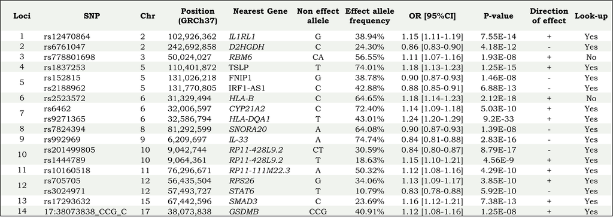

Table 1.Sentinel variants summary statistics. Chr=Chromosome; GRCh37=Genome Reference Consortium Human Build 37; OR=Odds Ratio; 95CI=Confidence Interval.

The three studies used for the look-up analyses revealed that 12 out of 14 loci has been already found associated with asthma or moderate-to-severe asthma (Table 2).

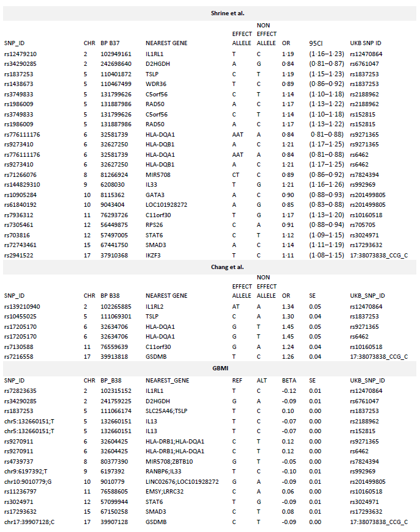

Table 2.Look-up sentinel variants. CHR=Chromosome; BP=Base position; B37=Build 37; B38=Build 38; OR=Odds Ratio; CI=95% Confidence Interval; UKB=UK Biobank.

# Conclusion

The GWAS revealed 7,198 genome-wide significant variants (p-value < 5 x 10-8), which represented 14 independent loci. Twelve of these loci had been previously reported in other studies, except those tagged by rs778801698 and rs2523572 on chromosome 3 and 6 respectively.

# References

1.Yang et al., 2011, Am J Hum Genet, doi:10.1016/j.ajhg.2010.11.011 2.Pruim RJ et al., 2010, Bioinformatics, doi:10.1093/bioinformatics/btq419 3.Shrine et al., 2019, Lancet Respir Med, doi:10.1016/S2213-2600(18)30389-8 4.Tsuo, K. et al. , 2022, Cell Genomics, doi:10.1016/j.xgen.2022.100212 5.Chang, D. et al. 2022, Sci Rep, doi: 10.1038/s41598-022-09447-8